# DS7333 - Case Study 15 | QTW Final Project

### Andy Ho, An Nguyen, Jodi Pafford

August 12, 2019

## Introduction

This report will provide our methods, model, analysis, and conclusions for the unlabeled data set provided. Along with that, the data cleaning process will be explained and details on our findings provided.  
To recap, we were assigned a dataset with 160,000 records and 51 features. According to our business partner, the data is related to the insurance industry. For the most part, the features were unlabeled – meaning the data has not been tagged identifying its characteristics, properties, or classifications. However, the target variable (i.e. dependent variable) is labeled (0 or 1). As a result, we will be looking at various supervised machine learning methods to arrive at our conclusions.  
For general background, supervised machine learning (SML) learns from the dataset to for classification and/or regression purposes. In this report, we will use the following methods for classification:

- Logistic Regression
- Decision Tree
- Random Forest
- Support Vector Machine
- K- Nearest Neighbor

The objective given by our business partner is to arrive at a model that best classifies the ‘y’ values (0 or 1). Hence, this is a classification problem and our conclusions will report the model with the best accuracy in classifying records/observations.  
What does classification mean? At its core, classification learns from the data given (i.e. training dataset) and then uses the findings to create a model to accurately classify new records. Along with accuracy, we will show the ratio of actual values to predicted values. As advised by our business partner, it is important to the business to accurately classify but even more so to lower the amount of ‘False Positives’ – mis-classifying a false positive could cost the business a thousand dollars while mis-classifying a false negative cost hundred dollars. Therefore, our objective is to arrive at the highest accuracy score with the lowest false positve ratio. Below is a graphic to help explain the possible outcomes:

[figure not shown]

## Our Process

The objective is to suggest/recommend Machine Learning models that would most accurately classify (with the lowest 'False Positives') the outcome ‘y.’ Our process was as follows:

1. Clean Data
2. Feature Select
3. Model
4. Analyze
5. Evaluate

## Clean Data

The raw data set was unlabeled. It contained a total of 160,000 records and 51 features. Using a Python library called ‘Pandas_Profiling’, we uncovered the following:

1. Datatypes  
   a. Numeric: 45  
   b. Categorical: 5  
   c. Boolean: 1
2. High Correlation  
   a. x41 – Dropped x41 from dataset  
   b. x6 – Dropped x6 from dataset
3. High Cardinality  
   a. x37 – The values had incorrect datatype – causing an incorrect assesessment of high cardinality. To clean it, we removed the commas and dollar sign, and replaced the parenthesis with a minus symbol. Converted datatype to numeric.
4. Data augmentation  
   a. Misspellings were present in x24. Corrected ‘euorpe’ to ‘europe’  
   b. Standardize values

   ```
   1.  x29 – Replaced all month abbreviations to full spelling (i.e. Aug to August)<br>
   2.  x30 – Corrected misspelling of ‘thurday’ to ‘thursday’<br>
   ```

## Feature Select

This portion took a bulk of our time. The process of feature selection was a continuous cycle between ‘feature select’ and ‘modeling.’ The first pass was to use the complete dataset with each subsequent iteration removing features and/or records.  
We attempted to reduce the number of features required through PCA. We found that 8 principal components can explain for 99.9% of the variance.  
Because this was a classification assignment, we selected a few classification models to find the best model for the data set (refer to ‘Model’ section for more details). In the end, we decided that all the categorical features made little to no impact on the accuracy scores – therefore, dropped.  
**Random Forest Feature Importance (RFFI)**  
Knowing feature importance allowed us to better understand the data set and provided insights to our feature selection process. After removing the categorical features, we ran RFFI for the remaining 45 features (using all 160,000 records) to arrive at the following feature of importance (>0.04):

## Modeling of Methods

We started to evaluate the SML methods stated above from the most common/basic to more complex. Each method selected utilized two versions of the data set to arrive at the method that yielded the best model (i.e. most accurate). The following will provide further detail into our process in sequential order of evaluation:  
**Logistic Regression (LR)**  
This method was the most obvious to run first since the dependent variable (‘y) was binary (0 or 1). The objective is to describe data and to explain the relationship between the dependent variable to the rest of the data set. Unfortunately, LR yielded the lowest accuracy rates in predicting the classification.

- Full Data Set: 70.27%
- Feature Selected: 70.33%

Logistic Regression Code

**Decision Tree (DT)**  
The goal of DT is to split the observations in a way that the resulting groups are as different from each other as much as possible. The structure of a tree is the root node, internal node, and leaf nodes – all of which are connected by branches. DT is the building block for Random Forest. The DT yielded better accuracy results compared to LR. XGBoost is a gradient boost to decision tree designed for speed and performance.

Decision Tree Code  
XGBoost Code

**Random Forest(RF)**  
RF uses a large number of uncorrelated decision trees to operate as a committee – much like an ensemble. Each DT outputs a class prediction and the class with the most votes is the RF’s optimal model prediction. The RF yielded better accuracy results compared to both LR and DT.

Random Forest Code

SVM Code

PCA Code

K-NN Code

## Analysis

With KNN, we started with the full dataset and k=5. After yielding somewhat high results on the first pass at the full dataset, we ran a KNN loop (with just the feature selected data) from k=1=k=25. Results can be seen below:

[figure not shown]

[figure not shown]

# Appendix

```python
import tkinter
import matplotlib
matplotlib.use('TkAgg')
import matplotlib.pyplot as plt
import pandas as pd
import numpy as np
import pandas_profiling as pp
import re

from sklearn.metrics import classification_report, confusion_matrix, accuracy_score
from sklearn.model_selection import train_test_split
from sklearn.preprocessing import StandardScaler
from sklearn.neighbors import KNeighborsClassifier
from sklearn import metrics
from sklearn.linear_model import LogisticRegression
from sklearn.tree import DecisionTreeClassifier, export_graphviz
from sklearn.externals.six import StringIO
from sklearn.decomposition import PCA
from sklearn.svm import SVC

from IPython.display import Image
from pydot import graph_from_dot_data

from mlxtend.plotting import plot_confusion_matrix
import random
import seaborn as sns
%matplotlib inline
```

## Load and Clean Data

```python
# Read in CSV
df = pd.read_csv("final_project.csv")
print(len(df))
```

```
160000
```

```python
# Rename obvious columns
df.rename(columns={'x24': 'continent', 'x29': 'month', 'x30': 'day'}, inplace = True)
#list(df.columns)
```

```python
# initialize temp for x37 column
temp_x37 = []

# Remove $ ) , characters and replace '(' with '-'
for i in range (0,len(df)) :
    try :
        n = df['x37'][i]
        nstr = re.sub(r'[$|,|)]',r'', n)
        nstr = re.sub(r'[(]',r'-',nstr)
        #nstr= float(nstr)
        temp_x37.append(nstr)
    except :
        nstr = ''
        temp_x37.append(nstr)
```

```python
# Verify len of both x37 matches
print(len(df['x37']))
print(len(temp_x37))

# Replace 'x37' with new values and convert to numeric
df['x37'] = temp_x37
df["x37"] = pd.to_numeric(df["x37"])
```

```
160000
160000
```

```python
# Correct misspellings and standardize values in labeled columns
df['continent'].replace('euorpe', 'europe',inplace=True)
df['month'].replace('Dev', 'December',inplace=True)
df['month'].replace('Aug', 'August',inplace=True)
df['month'].replace('Jun', 'June',inplace=True)
df['month'].replace('Apr', 'April',inplace=True)
df['month'].replace('Nov', 'November',inplace=True)
df['month'].replace('sept.', 'September',inplace=True)
df['month'].replace('Oct', 'October',inplace=True)
df['month'].replace('Mar', 'March',inplace=True)
df['day'].replace('thurday', 'thursday',inplace=True)

# Fill NA with 'other' in labeled columns
df['continent'] = df['continent'].fillna('other')
df['month'] = df['month'].fillna('other')
df['day'] = df['day'].fillna('other')

# check unique values in labeled columns
print (df['continent'].unique())
print (df['month'].unique())
print (df['day'].unique())
```

```
['europe' 'asia' 'america' 'other']
['July' 'August' 'June' 'May' 'September' 'April' 'November' 'October'
 'other' 'March' 'Feb' 'December' 'January']
['tuesday' 'wednesday' 'thursday' 'monday' 'friday' 'other']
```

```python
# Correct misspellings and standardize values in labeled columns
df['continent'].replace('euorpe', 'europe',inplace=True)
df['month'].replace('Dev', '12',inplace=True)
df['month'].replace('Aug', '8',inplace=True)
df['month'].replace('Jun', '6',inplace=True)
df['month'].replace('Apr', '4',inplace=True)
df['month'].replace('Nov', '11',inplace=True)
df['month'].replace('sept.', '9',inplace=True)
df['month'].replace('Oct', '10',inplace=True)
df['month'].replace('Mar', '3',inplace=True)
df['month'].replace('January', '1',inplace=True)
df['month'].replace('Feb', '2',inplace=True)
df['month'].replace('May', '5',inplace=True)
df['month'].replace('July', '7',inplace=True)
df['month'].replace('December', '12',inplace=True)
df['month'].replace('August', '8',inplace=True)
df['month'].replace('June', '6',inplace=True)
df['month'].replace('April', '4',inplace=True)
df['month'].replace('November', '11',inplace=True)
df['month'].replace('September', '9',inplace=True)
df['month'].replace('October', '10',inplace=True)
df['month'].replace('March', '3',inplace=True)
df['day'].replace('thurday', 'thursday',inplace=True)


# Fill NA with 'other' in labeled columns
df['continent'] = df['continent'].fillna('other')
df['month'] = df['month'].fillna('other')
df['day'] = df['day'].fillna('other')
df['month'].replace('other','0', inplace=True)

# check unique values in labeled columns
print (df['continent'].unique())
print (df['month'].unique())
print (df['day'].unique())
```

```
['europe' 'asia' 'america' 'other']
['7' '8' '6' '5' '9' '4' '11' '10' '0' '3' '2' '12' '1']
['tuesday' 'wednesday' 'thursday' 'monday' 'friday' 'other']
```

```python
# Subsetting data set by continent and print length of each
cont = ['asia', 'america','europe', 'other']

for n in cont :
    temp = df['continent'] == n
    df_temp = df[temp]
    #df_[n] = df_temp
    print (n, 'length is', len(df_temp))

# Subsetting by continent
is_asia = df['continent']=='asia'
df_asia = df[is_asia]

is_europe = df['continent']=='europe'
df_europe = df[is_europe]

is_america = df['continent']=='america'
df_america = df[is_america]

is_other = df['continent']=='other'
df_other = df[is_other]
```

```
asia length is 138965
america length is 4469
europe length is 16538
other length is 28
```

## Explore Data

Overview

Dataset info

| Number of variables | 52 |
| --- | --- |
| Number of observations | 4469 |
| Total Missing (%) | 0.0% |
| Total size in memory | 1.8 MiB |
| Average record size in memory | 416.0 B |

Variables types

| Numeric | 45 |
| --- | --- |
| Categorical | 3 |
| Boolean | 1 |
| Date | 0 |
| Text (Unique) | 0 |
| Rejected | 3 |
| Unsupported | 0 |

Warnings

- `x6` is highly correlated with `x2` (ρ = 1) Rejected

- `continent` has constant value america Rejected

- `x41` is highly correlated with `x38` (ρ = 1) Rejected

Variables

index  
Numeric

| Distinct count | 4469 |
| --- | --- |
| Unique (%) | 100.0% |
| Missing (%) | 0.0% |
| Missing (n) | 0 |
| Infinite (%) | 0.0% |
| Infinite (n) | 0 |

| Mean | 80692 |
| --- | --- |
| Minimum | 11 |
| Maximum | 159992 |
| Zeros (%) | 0.0% |

Toggle details

**Statistics**

Quantile statistics

| Minimum | 11 |
| --- | --- |
| 5-th percentile | 7889.6 |
| Q1 | 40450 |
| Median | 80882 |
| Q3 | 121250 |
| 95-th percentile | 151870 |
| Maximum | 159992 |
| Range | 159981 |
| Interquartile range | 80804 |

Descriptive statistics

| Standard deviation | 46306 |
| --- | --- |
| Coef of variation | 0.57386 |
| Kurtosis | -1.221 |
| Mean | 80692 |
| MAD | 40280 |
| Skewness | -0.024556 |
| Sum | 360614096 |
| Variance | 2144200000 |
| Memory size | 35.0 KiB |

**Histogram**

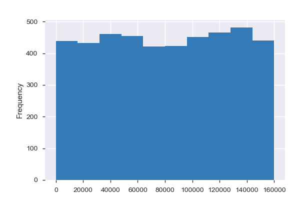

**Common Values**

| Value | Count | Frequency (%) |  |
| --- | --- | --- | --- |
| 81916 | 1 | 0.0% |  |
| 47754 | 1 | 0.0% |  |
| 68224 | 1 | 0.0% |  |
| 123521 | 1 | 0.0% |  |
| 115197 | 1 | 0.0% |  |
| 19076 | 1 | 0.0% |  |
| 113286 | 1 | 0.0% |  |
| 12935 | 1 | 0.0% |  |
| 119435 | 1 | 0.0% |  |
| 24674 | 1 | 0.0% |  |
| Other values (4459) | 4459 | 99.8% |  |

**Extreme Values**

Minimum 5 values

| Value | Count | Frequency (%) |  |
| --- | --- | --- | --- |
| 11 | 1 | 0.0% |  |
| 30 | 1 | 0.0% |  |
| 39 | 1 | 0.0% |  |
| 69 | 1 | 0.0% |  |
| 93 | 1 | 0.0% |  |

Maximum 5 values

| Value | Count | Frequency (%) |  |
| --- | --- | --- | --- |
| 159901 | 1 | 0.0% |  |
| 159912 | 1 | 0.0% |  |
| 159920 | 1 | 0.0% |  |
| 159987 | 1 | 0.0% |  |
| 159992 | 1 | 0.0% |  |

x0  
Numeric

| Distinct count | 4469 |
| --- | --- |
| Unique (%) | 100.0% |
| Missing (%) | 0.0% |
| Missing (n) | 1 |
| Infinite (%) | 0.0% |
| Infinite (n) | 0 |

| Mean | -0.0011259 |
| --- | --- |
| Minimum | -1.4799 |
| Maximum | 1.4695 |
| Zeros (%) | 0.0% |

Toggle details

**Statistics**

Quantile statistics

| Minimum | -1.4799 |
| --- | --- |
| 5-th percentile | -0.61205 |
| Q1 | -0.25995 |
| Median | 0.0016202 |
| Q3 | 0.2546 |
| 95-th percentile | 0.60987 |
| Maximum | 1.4695 |
| Range | 2.9494 |
| Interquartile range | 0.51455 |

Descriptive statistics

| Standard deviation | 0.37348 |
| --- | --- |
| Coef of variation | -331.7 |
| Kurtosis | -0.095404 |
| Mean | -0.0011259 |
| MAD | 0.30019 |
| Skewness | 0.0063479 |
| Sum | -5.0307 |
| Variance | 0.13948 |
| Memory size | 35.0 KiB |

**Histogram**

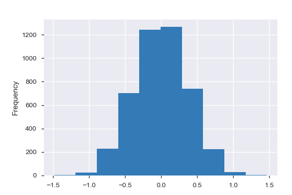

**Common Values**

| Value | Count | Frequency (%) |  |
| --- | --- | --- | --- |
| -0.057825872559253214 | 1 | 0.0% |  |
| -0.12083968126419445 | 1 | 0.0% |  |
| 0.3631663378270901 | 1 | 0.0% |  |
| -0.16002392994808515 | 1 | 0.0% |  |
| 0.11704868535375786 | 1 | 0.0% |  |
| -0.029843646205759806 | 1 | 0.0% |  |
| 0.2000907816706446 | 1 | 0.0% |  |
| 0.9393589529946952 | 1 | 0.0% |  |
| 0.10884046228200664 | 1 | 0.0% |  |
| 0.22348331387325426 | 1 | 0.0% |  |
| Other values (4458) | 4458 | 99.8% |  |

**Extreme Values**

Minimum 5 values

| Value | Count | Frequency (%) |  |
| --- | --- | --- | --- |
| -1.479927324820506 | 1 | 0.0% |  |
| -1.308940171853241 | 1 | 0.0% |  |
| -1.2203676249592703 | 1 | 0.0% |  |
| -1.1662523583455482 | 1 | 0.0% |  |
| -1.135280098338538 | 1 | 0.0% |  |

Maximum 5 values

| Value | Count | Frequency (%) |  |
| --- | --- | --- | --- |
| 1.1598133469471033 | 1 | 0.0% |  |
| 1.250157018593822 | 1 | 0.0% |  |
| 1.2668684740207026 | 1 | 0.0% |  |
| 1.3621380505513272 | 1 | 0.0% |  |
| 1.469505160621286 | 1 | 0.0% |  |

x1  
Numeric

| Distinct count | 4469 |
| --- | --- |
| Unique (%) | 100.0% |
| Missing (%) | 0.0% |
| Missing (n) | 0 |
| Infinite (%) | 0.0% |
| Infinite (n) | 0 |

| Mean | -0.045134 |
| --- | --- |
| Minimum | -22.261 |
| Maximum | 21.876 |
| Zeros (%) | 0.0% |

Toggle details

**Statistics**

Quantile statistics

| Minimum | -22.261 |
| --- | --- |
| 5-th percentile | -10.483 |
| Q1 | -4.391 |
| Median | -0.09152 |
| Q3 | 4.1298 |
| 95-th percentile | 10.629 |
| Maximum | 21.876 |
| Range | 44.137 |
| Interquartile range | 8.5208 |

Descriptive statistics

| Standard deviation | 6.3591 |
| --- | --- |
| Coef of variation | -140.89 |
| Kurtosis | 0.0040874 |
| Mean | -0.045134 |
| MAD | 5.059 |
| Skewness | 0.0060594 |
| Sum | -201.71 |
| Variance | 40.439 |
| Memory size | 35.0 KiB |

**Histogram**

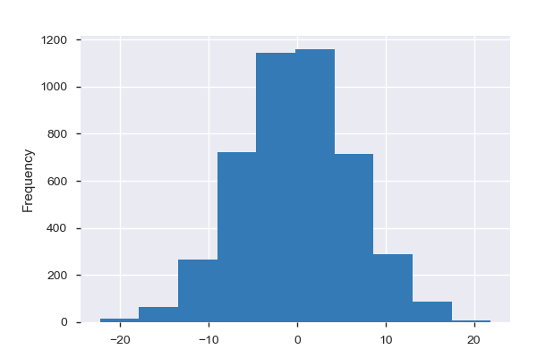

**Common Values**

| Value | Count | Frequency (%) |  |
| --- | --- | --- | --- |
| -12.113527565857536 | 1 | 0.0% |  |
| -7.6481104578237 | 1 | 0.0% |  |
| 1.7252467571408219 | 1 | 0.0% |  |
| -0.2692326681571991 | 1 | 0.0% |  |
| -1.1763316146272849 | 1 | 0.0% |  |
| 1.9299941470287063 | 1 | 0.0% |  |
| 3.4553142368068164 | 1 | 0.0% |  |
| 2.0962127597377886 | 1 | 0.0% |  |
| 3.3836244003754934 | 1 | 0.0% |  |
| 6.814520683297565 | 1 | 0.0% |  |
| Other values (4459) | 4459 | 99.8% |  |

**Extreme Values**

Minimum 5 values

| Value | Count | Frequency (%) |  |
| --- | --- | --- | --- |
| -22.26074144865308 | 1 | 0.0% |  |
| -22.225809877889038 | 1 | 0.0% |  |
| -20.88317176882016 | 1 | 0.0% |  |
| -20.58886901596813 | 1 | 0.0% |  |
| -20.233787630773424 | 1 | 0.0% |  |

Maximum 5 values

| Value | Count | Frequency (%) |  |
| --- | --- | --- | --- |
| 18.5025585255357 | 1 | 0.0% |  |
| 18.68135847280788 | 1 | 0.0% |  |
| 18.73701997769821 | 1 | 0.0% |  |
| 21.5185830985432 | 1 | 0.0% |  |
| 21.87625842559403 | 1 | 0.0% |  |

x2  
Numeric

| Distinct count | 4469 |
| --- | --- |
| Unique (%) | 100.0% |
| Missing (%) | 0.0% |
| Missing (n) | 0 |
| Infinite (%) | 0.0% |
| Infinite (n) | 0 |

| Mean | 0.48552 |
| --- | --- |
| Minimum | -50.56 |
| Maximum | 49.259 |
| Zeros (%) | 0.0% |

Toggle details

**Statistics**

Quantile statistics

| Minimum | -50.56 |
| --- | --- |
| 5-th percentile | -20.557 |
| Q1 | -7.9238 |
| Median | 0.51785 |
| Q3 | 9.3742 |
| 95-th percentile | 21.094 |
| Maximum | 49.259 |
| Range | 99.819 |
| Interquartile range | 17.298 |

Descriptive statistics

| Standard deviation | 12.907 |
| --- | --- |
| Coef of variation | 26.585 |
| Kurtosis | 0.22895 |
| Mean | 0.48552 |
| MAD | 10.239 |
| Skewness | -0.11809 |
| Sum | 2169.8 |
| Variance | 166.6 |
| Memory size | 35.0 KiB |

**Histogram**

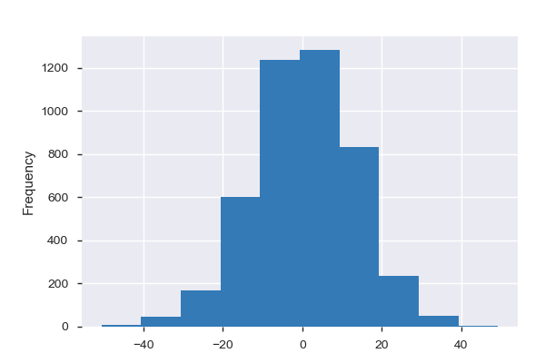

**Common Values**

| Value | Count | Frequency (%) |  |
| --- | --- | --- | --- |
| 25.70469269947881 | 1 | 0.0% |  |
| 3.7891137072323082 | 1 | 0.0% |  |
| -15.70421672730438 | 1 | 0.0% |  |
| -17.92293786269011 | 1 | 0.0% |  |
| 25.81606837829421 | 1 | 0.0% |  |
| 8.127096522851517 | 1 | 0.0% |  |
| 11.455684037135056 | 1 | 0.0% |  |
| -1.4160410459061712 | 1 | 0.0% |  |
| 1.5137499520448598 | 1 | 0.0% |  |
| 16.927624072074213 | 1 | 0.0% |  |
| Other values (4459) | 4459 | 99.8% |  |

**Extreme Values**

Minimum 5 values

| Value | Count | Frequency (%) |  |
| --- | --- | --- | --- |
| -50.560168344231826 | 1 | 0.0% |  |
| -50.36327729364695 | 1 | 0.0% |  |
| -48.6434927907919 | 1 | 0.0% |  |
| -46.193410421802156 | 1 | 0.0% |  |
| -43.06075730418448 | 1 | 0.0% |  |

Maximum 5 values

| Value | Count | Frequency (%) |  |
| --- | --- | --- | --- |
| 37.871908128979825 | 1 | 0.0% |  |
| 41.8253044966414 | 1 | 0.0% |  |
| 42.359017645195365 | 1 | 0.0% |  |
| 47.39042900018739 | 1 | 0.0% |  |
| 49.25927735376687 | 1 | 0.0% |  |

x3  
Numeric

| Distinct count | 4469 |
| --- | --- |
| Unique (%) | 100.0% |
| Missing (%) | 0.0% |
| Missing (n) | 1 |
| Infinite (%) | 0.0% |
| Infinite (n) | 0 |

| Mean | -0.21077 |
| --- | --- |
| Minimum | -33.865 |
| Maximum | 29.078 |
| Zeros (%) | 0.0% |

Toggle details

**Statistics**

Quantile statistics

| Minimum | -33.865 |
| --- | --- |
| 5-th percentile | -13.367 |
| Q1 | -5.742 |
| Median | -0.092809 |
| Q3 | 5.4121 |
| 95-th percentile | 12.741 |
| Maximum | 29.078 |
| Range | 62.943 |
| Interquartile range | 11.154 |

Descriptive statistics

| Standard deviation | 8.092 |
| --- | --- |
| Coef of variation | -38.393 |
| Kurtosis | 0.037261 |
| Mean | -0.21077 |
| MAD | 6.4633 |
| Skewness | -0.027111 |
| Sum | -941.72 |
| Variance | 65.48 |
| Memory size | 35.0 KiB |

**Histogram**

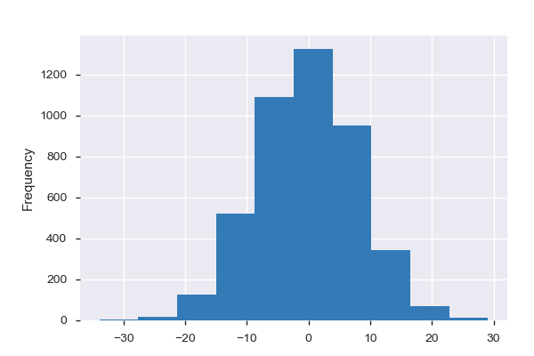

**Common Values**

| Value | Count | Frequency (%) |  |
| --- | --- | --- | --- |
| 5.217910981142366 | 1 | 0.0% |  |
| 10.828260414367161 | 1 | 0.0% |  |
| 0.5750027291758699 | 1 | 0.0% |  |
| 2.4497869525109848 | 1 | 0.0% |  |
| 7.964575295842072 | 1 | 0.0% |  |
| 1.5240573049293178 | 1 | 0.0% |  |
| 2.159707072207002 | 1 | 0.0% |  |
| 4.139054265636728 | 1 | 0.0% |  |
| -4.487735475037691 | 1 | 0.0% |  |
| -5.47532950836148 | 1 | 0.0% |  |
| Other values (4458) | 4458 | 99.8% |  |

**Extreme Values**

Minimum 5 values

| Value | Count | Frequency (%) |  |
| --- | --- | --- | --- |
| -33.86482705623085 | 1 | 0.0% |  |
| -28.323583964846677 | 1 | 0.0% |  |
| -28.210547613616363 | 1 | 0.0% |  |
| -27.635574094085136 | 1 | 0.0% |  |
| -25.52826196589439 | 1 | 0.0% |  |

Maximum 5 values

| Value | Count | Frequency (%) |  |
| --- | --- | --- | --- |
| 25.999752451403452 | 1 | 0.0% |  |
| 26.443585123118602 | 1 | 0.0% |  |
| 26.836089116123308 | 1 | 0.0% |  |
| 26.875774353592483 | 1 | 0.0% |  |
| 29.07819356708271 | 1 | 0.0% |  |

x4  
Numeric

| Distinct count | 4467 |
| --- | --- |
| Unique (%) | 100.0% |
| Missing (%) | 0.1% |
| Missing (n) | 3 |
| Infinite (%) | 0.0% |
| Infinite (n) | 0 |

| Mean | 0.15582 |
| --- | --- |
| Minimum | -22.071 |
| Maximum | 22.972 |
| Zeros (%) | 0.0% |

Toggle details

**Statistics**

Quantile statistics

| Minimum | -22.071 |
| --- | --- |
| 5-th percentile | -10.428 |
| Q1 | -4.299 |
| Median | 0.22065 |
| Q3 | 4.5052 |
| 95-th percentile | 10.607 |
| Maximum | 22.972 |
| Range | 45.043 |
| Interquartile range | 8.8042 |

Descriptive statistics

| Standard deviation | 6.4016 |
| --- | --- |
| Coef of variation | 41.083 |
| Kurtosis | -0.045178 |
| Mean | 0.15582 |
| MAD | 5.1149 |
| Skewness | 0.0080131 |
| Sum | 695.9 |
| Variance | 40.981 |
| Memory size | 35.0 KiB |

**Histogram**

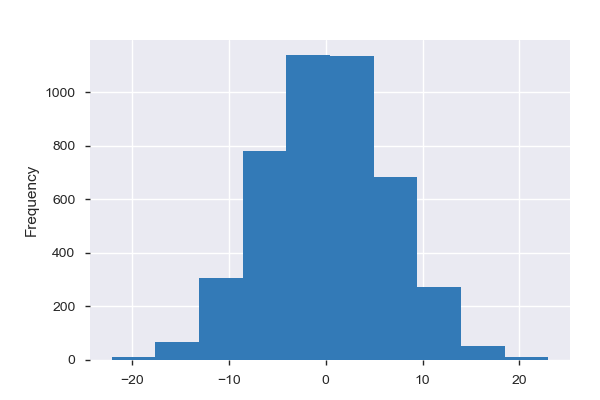

**Common Values**

| Value | Count | Frequency (%) |  |
| --- | --- | --- | --- |
| -5.8622610812068405 | 1 | 0.0% |  |
| 3.960285287944069 | 1 | 0.0% |  |
| -11.693648663626115 | 1 | 0.0% |  |
| 2.343155048686268 | 1 | 0.0% |  |
| -8.110083995186269 | 1 | 0.0% |  |
| 7.7305717531736615 | 1 | 0.0% |  |
| -3.792110776902701 | 1 | 0.0% |  |
| -7.28663336686937 | 1 | 0.0% |  |
| 6.4306734609140275 | 1 | 0.0% |  |
| -17.17908019406292 | 1 | 0.0% |  |
| Other values (4456) | 4456 | 99.7% |  |
| (Missing) | 3 | 0.1% |  |

**Extreme Values**

Minimum 5 values

| Value | Count | Frequency (%) |  |
| --- | --- | --- | --- |
| -22.07064764334438 | 1 | 0.0% |  |
| -21.79928873217019 | 1 | 0.0% |  |
| -20.572153325778967 | 1 | 0.0% |  |
| -19.74270561639045 | 1 | 0.0% |  |
| -19.28524664071549 | 1 | 0.0% |  |

Maximum 5 values

| Value | Count | Frequency (%) |  |
| --- | --- | --- | --- |
| 19.892095813081518 | 1 | 0.0% |  |
| 19.98130778235576 | 1 | 0.0% |  |
| 21.506094148265767 | 1 | 0.0% |  |
| 22.236353210291558 | 1 | 0.0% |  |
| 22.972433446849422 | 1 | 0.0% |  |

x5  
Numeric

| Distinct count | 4469 |
| --- | --- |
| Unique (%) | 100.0% |
| Missing (%) | 0.0% |
| Missing (n) | 1 |
| Infinite (%) | 0.0% |
| Infinite (n) | 0 |

| Mean | -0.089797 |
| --- | --- |
| Minimum | -29.068 |
| Maximum | 28.053 |
| Zeros (%) | 0.0% |

Toggle details

**Statistics**

Quantile statistics

| Minimum | -29.068 |
| --- | --- |
| 5-th percentile | -13.072 |
| Q1 | -5.2331 |
| Median | -0.21045 |
| Q3 | 5.2261 |
| 95-th percentile | 12.947 |
| Maximum | 28.053 |
| Range | 57.121 |
| Interquartile range | 10.459 |

Descriptive statistics

| Standard deviation | 7.8566 |
| --- | --- |
| Coef of variation | -87.492 |
| Kurtosis | -0.020625 |
| Mean | -0.089797 |
| MAD | 6.2631 |
| Skewness | -0.0060831 |
| Sum | -401.21 |
| Variance | 61.726 |
| Memory size | 35.0 KiB |

**Histogram**

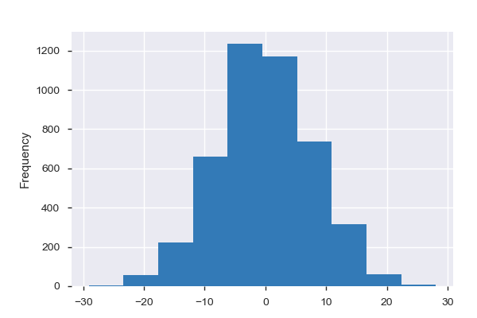

**Common Values**

| Value | Count | Frequency (%) |  |
| --- | --- | --- | --- |
| -4.5513022682177215 | 1 | 0.0% |  |
| -8.657916020010335 | 1 | 0.0% |  |
| -10.129011896291363 | 1 | 0.0% |  |
| -13.26851584683671 | 1 | 0.0% |  |
| 7.688712913003206 | 1 | 0.0% |  |
| -10.614400248810767 | 1 | 0.0% |  |
| -13.419193337155106 | 1 | 0.0% |  |
| -2.766459369813969 | 1 | 0.0% |  |
| -1.877565684244182 | 1 | 0.0% |  |
| -4.821896554287823 | 1 | 0.0% |  |
| Other values (4458) | 4458 | 99.8% |  |

**Extreme Values**

Minimum 5 values

| Value | Count | Frequency (%) |  |
| --- | --- | --- | --- |
| -29.06837329246414 | 1 | 0.0% |  |
| -26.217484700340208 | 1 | 0.0% |  |
| -25.490972448814066 | 1 | 0.0% |  |
| -25.223511465218635 | 1 | 0.0% |  |
| -23.722588585540038 | 1 | 0.0% |  |

Maximum 5 values

| Value | Count | Frequency (%) |  |
| --- | --- | --- | --- |
| 23.58836128634839 | 1 | 0.0% |  |
| 24.546023878494612 | 1 | 0.0% |  |
| 25.148455276279503 | 1 | 0.0% |  |
| 25.644343748114625 | 1 | 0.0% |  |
| 28.052835218154026 | 1 | 0.0% |  |

x6  
Highly correlated

*This variable is highly correlated with `x2` and should be ignored for analysis*

| Correlation | 1 |
| --- | --- |

x7  
Numeric

| Distinct count | 4469 |
| --- | --- |
| Unique (%) | 100.0% |
| Missing (%) | 0.0% |
| Missing (n) | 1 |
| Infinite (%) | 0.0% |
| Infinite (n) | 0 |

| Mean | 16.86 |
| --- | --- |
| Minimum | -98.747 |
| Maximum | 130.99 |
| Zeros (%) | 0.0% |

Toggle details

**Statistics**

Quantile statistics

| Minimum | -98.747 |
| --- | --- |
| 5-th percentile | -34.438 |
| Q1 | -2.7079 |
| Median | 17.242 |
| Q3 | 37.129 |
| 95-th percentile | 65.9 |
| Maximum | 130.99 |
| Range | 229.74 |
| Interquartile range | 39.837 |

Descriptive statistics

| Standard deviation | 30.34 |
| --- | --- |
| Coef of variation | 1.7995 |
| Kurtosis | 0.27659 |
| Mean | 16.86 |
| MAD | 23.888 |
| Skewness | -0.090203 |
| Sum | 75330 |
| Variance | 920.52 |
| Memory size | 35.0 KiB |

**Histogram**

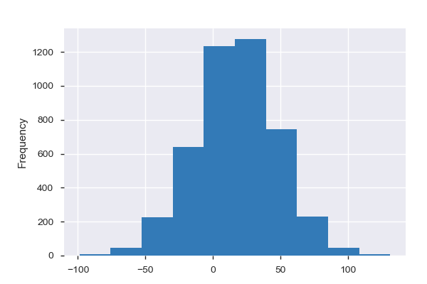

**Common Values**

| Value | Count | Frequency (%) |  |
| --- | --- | --- | --- |
| 52.40534143765045 | 1 | 0.0% |  |
| 29.29422963047417 | 1 | 0.0% |  |
| -6.322979565940579 | 1 | 0.0% |  |
| 45.58760393121211 | 1 | 0.0% |  |
| 11.573897152040553 | 1 | 0.0% |  |
| -1.7535926448332992 | 1 | 0.0% |  |
| 36.737700394321884 | 1 | 0.0% |  |
| 11.514521566071114 | 1 | 0.0% |  |
| 4.878837112541796 | 1 | 0.0% |  |
| -38.544103573877024 | 1 | 0.0% |  |
| Other values (4458) | 4458 | 99.8% |  |

**Extreme Values**

Minimum 5 values

| Value | Count | Frequency (%) |  |
| --- | --- | --- | --- |
| -98.7472338814783 | 1 | 0.0% |  |
| -98.12880835450441 | 1 | 0.0% |  |
| -94.71936338105118 | 1 | 0.0% |  |
| -89.07251723306439 | 1 | 0.0% |  |
| -88.464237522865 | 1 | 0.0% |  |

Maximum 5 values

| Value | Count | Frequency (%) |  |
| --- | --- | --- | --- |
| 112.57661358816836 | 1 | 0.0% |  |
| 113.0648486363908 | 1 | 0.0% |  |
| 117.11163880498812 | 1 | 0.0% |  |
| 129.91875516336086 | 1 | 0.0% |  |
| 130.98991016568792 | 1 | 0.0% |  |

x8  
Numeric

| Distinct count | 4468 |
| --- | --- |
| Unique (%) | 100.0% |
| Missing (%) | 0.0% |
| Missing (n) | 2 |
| Infinite (%) | 0.0% |
| Infinite (n) | 0 |

| Mean | 0.029826 |
| --- | --- |
| Minimum | -32.801 |
| Maximum | 28.608 |
| Zeros (%) | 0.0% |

Toggle details

**Statistics**

Quantile statistics

| Minimum | -32.801 |
| --- | --- |
| 5-th percentile | -14.862 |
| Q1 | -5.9616 |
| Median | -0.048961 |
| Q3 | 6.1108 |
| 95-th percentile | 14.865 |
| Maximum | 28.608 |
| Range | 61.409 |
| Interquartile range | 12.072 |

Descriptive statistics

| Standard deviation | 8.9954 |
| --- | --- |
| Coef of variation | 301.59 |
| Kurtosis | -0.00086557 |
| Mean | 0.029826 |
| MAD | 7.174 |
| Skewness | -0.034713 |
| Sum | 133.23 |
| Variance | 80.917 |
| Memory size | 35.0 KiB |

**Histogram**

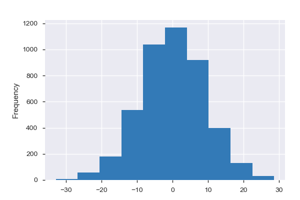

**Common Values**

| Value | Count | Frequency (%) |  |
| --- | --- | --- | --- |
| -1.7328206231170031 | 1 | 0.0% |  |
| -8.277942039355175 | 1 | 0.0% |  |
| -9.423148271256183 | 1 | 0.0% |  |
| -10.926642180143778 | 1 | 0.0% |  |
| -9.827960242972654 | 1 | 0.0% |  |
| 8.934756695120988 | 1 | 0.0% |  |
| -5.269642586903559 | 1 | 0.0% |  |
| 0.7035174724806882 | 1 | 0.0% |  |
| -13.244458336636006 | 1 | 0.0% |  |
| 18.12168494253748 | 1 | 0.0% |  |
| Other values (4457) | 4457 | 99.7% |  |
| (Missing) | 2 | 0.0% |  |

**Extreme Values**

Minimum 5 values

| Value | Count | Frequency (%) |  |
| --- | --- | --- | --- |
| -32.800532912430214 | 1 | 0.0% |  |
| -29.389953845335754 | 1 | 0.0% |  |
| -29.294782259332965 | 1 | 0.0% |  |
| -28.335129604758887 | 1 | 0.0% |  |
| -27.393861093561522 | 1 | 0.0% |  |

Maximum 5 values

| Value | Count | Frequency (%) |  |
| --- | --- | --- | --- |
| 25.83288525391406 | 1 | 0.0% |  |
| 26.44824580828925 | 1 | 0.0% |  |
| 26.631867313760356 | 1 | 0.0% |  |
| 27.905676584072637 | 1 | 0.0% |  |
| 28.608463807913928 | 1 | 0.0% |  |

x9  
Numeric

| Distinct count | 4469 |
| --- | --- |
| Unique (%) | 100.0% |
| Missing (%) | 0.0% |
| Missing (n) | 0 |
| Infinite (%) | 0.0% |
| Infinite (n) | 0 |

| Mean | 0.024181 |
| --- | --- |
| Minimum | -20.659 |
| Maximum | 26.138 |
| Zeros (%) | 0.0% |

Toggle details

**Statistics**

Quantile statistics

| Minimum | -20.659 |
| --- | --- |
| 5-th percentile | -10.355 |
| Q1 | -4.263 |
| Median | 0.022617 |
| Q3 | 4.2343 |
| 95-th percentile | 10.372 |
| Maximum | 26.138 |
| Range | 46.797 |
| Interquartile range | 8.4973 |

Descriptive statistics

| Standard deviation | 6.2644 |
| --- | --- |
| Coef of variation | 259.06 |
| Kurtosis | 0.0059922 |
| Mean | 0.024181 |
| MAD | 4.9926 |
| Skewness | 0.04764 |
| Sum | 108.06 |
| Variance | 39.243 |
| Memory size | 35.0 KiB |

**Histogram**

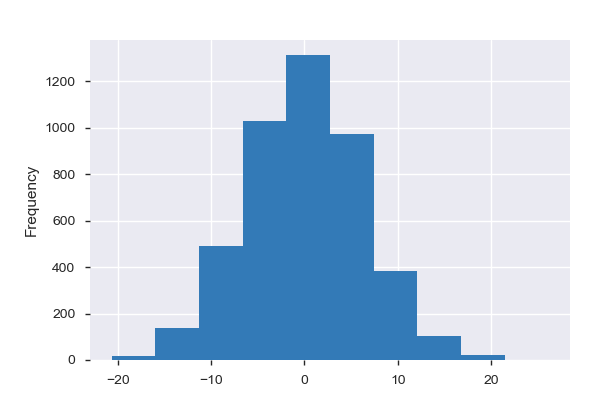

**Common Values**

| Value | Count | Frequency (%) |  |
| --- | --- | --- | --- |
| -2.8621648603890595 | 1 | 0.0% |  |
| -7.261046066467135 | 1 | 0.0% |  |
| 6.500859939537567 | 1 | 0.0% |  |
| 1.52870483464223 | 1 | 0.0% |  |
| -1.8697786249904755 | 1 | 0.0% |  |
| 0.44644693660512413 | 1 | 0.0% |  |
| -3.05674854518754 | 1 | 0.0% |  |
| 0.5539905271210673 | 1 | 0.0% |  |
| -4.928341304211387 | 1 | 0.0% |  |
| -2.35602599251502 | 1 | 0.0% |  |
| Other values (4459) | 4459 | 99.8% |  |

**Extreme Values**

Minimum 5 values

| Value | Count | Frequency (%) |  |
| --- | --- | --- | --- |
| -20.658569063288912 | 1 | 0.0% |  |
| -20.481424996491533 | 1 | 0.0% |  |
| -20.0028074654825 | 1 | 0.0% |  |
| -19.269322443178822 | 1 | 0.0% |  |
| -18.83272646204006 | 1 | 0.0% |  |

Maximum 5 values

| Value | Count | Frequency (%) |  |
| --- | --- | --- | --- |
| 19.75113367577514 | 1 | 0.0% |  |
| 19.785859422228746 | 1 | 0.0% |  |
| 20.193179697678946 | 1 | 0.0% |  |
| 20.429922571021052 | 1 | 0.0% |  |
| 26.1382764799984 | 1 | 0.0% |  |

x10  
Numeric

| Distinct count | 4469 |
| --- | --- |
| Unique (%) | 100.0% |
| Missing (%) | 0.0% |
| Missing (n) | 1 |
| Infinite (%) | 0.0% |
| Infinite (n) | 0 |

| Mean | -0.069416 |
| --- | --- |
| Minimum | -31.87 |
| Maximum | 30.603 |
| Zeros (%) | 0.0% |

Toggle details

**Statistics**

Quantile statistics

| Minimum | -31.87 |
| --- | --- |
| 5-th percentile | -12.985 |
| Q1 | -5.4861 |
| Median | -0.032922 |
| Q3 | 5.4115 |
| 95-th percentile | 12.688 |
| Maximum | 30.603 |
| Range | 62.473 |
| Interquartile range | 10.898 |

Descriptive statistics

| Standard deviation | 7.9284 |
| --- | --- |
| Coef of variation | -114.22 |
| Kurtosis | -0.018637 |
| Mean | -0.069416 |
| MAD | 6.3376 |
| Skewness | -0.032119 |
| Sum | -310.15 |
| Variance | 62.859 |
| Memory size | 35.0 KiB |

**Histogram**

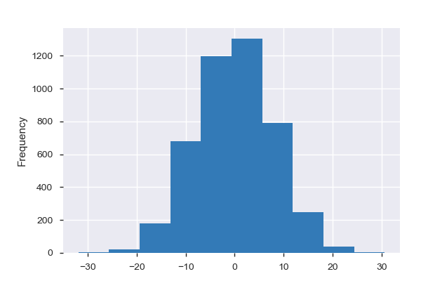

**Common Values**

| Value | Count | Frequency (%) |  |
| --- | --- | --- | --- |
| -0.05259592100066167 | 1 | 0.0% |  |
| 2.287912273297035 | 1 | 0.0% |  |
| 9.985691717956152 | 1 | 0.0% |  |
| -12.139593448217724 | 1 | 0.0% |  |
| -6.016268053903916 | 1 | 0.0% |  |
| 4.647643852746413 | 1 | 0.0% |  |
| -12.514741234012515 | 1 | 0.0% |  |
| 9.4800369170275 | 1 | 0.0% |  |
| 2.1471250348036417 | 1 | 0.0% |  |
| -0.2204986370753552 | 1 | 0.0% |  |
| Other values (4458) | 4458 | 99.8% |  |

**Extreme Values**

Minimum 5 values

| Value | Count | Frequency (%) |  |
| --- | --- | --- | --- |
| -31.87039233755074 | 1 | 0.0% |  |
| -29.3427080856351 | 1 | 0.0% |  |
| -28.284163599657283 | 1 | 0.0% |  |
| -27.669686264258214 | 1 | 0.0% |  |
| -25.87189582902308 | 1 | 0.0% |  |

Maximum 5 values

| Value | Count | Frequency (%) |  |
| --- | --- | --- | --- |
| 22.6142900424927 | 1 | 0.0% |  |
| 24.30680563762693 | 1 | 0.0% |  |
| 28.23889348094098 | 1 | 0.0% |  |
| 28.33332929237465 | 1 | 0.0% |  |
| 30.6027872968988 | 1 | 0.0% |  |

x11  
Numeric

| Distinct count | 4469 |
| --- | --- |
| Unique (%) | 100.0% |
| Missing (%) | 0.0% |
| Missing (n) | 1 |
| Infinite (%) | 0.0% |
| Infinite (n) | 0 |

| Mean | -0.042828 |
| --- | --- |
| Minimum | -30.24 |
| Maximum | 29.509 |
| Zeros (%) | 0.0% |

Toggle details

**Statistics**

Quantile statistics

| Minimum | -30.24 |
| --- | --- |
| 5-th percentile | -14.422 |
| Q1 | -5.9468 |
| Median | -0.1585 |
| Q3 | 5.8745 |
| 95-th percentile | 14.599 |
| Maximum | 29.509 |
| Range | 59.749 |
| Interquartile range | 11.821 |

Descriptive statistics

| Standard deviation | 8.8166 |
| --- | --- |
| Coef of variation | -205.86 |
| Kurtosis | -0.041036 |
| Mean | -0.042828 |
| MAD | 7.0031 |
| Skewness | 0.015766 |
| Sum | -191.36 |
| Variance | 77.733 |
| Memory size | 35.0 KiB |

**Histogram**

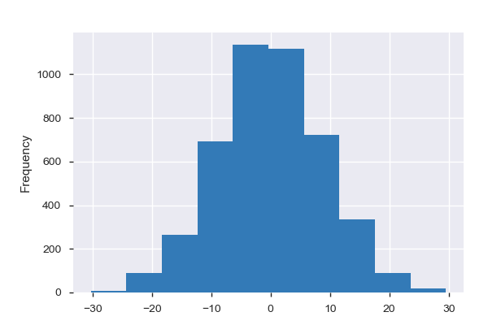

**Common Values**

| Value | Count | Frequency (%) |  |
| --- | --- | --- | --- |
| -5.497349499203386 | 1 | 0.0% |  |
| 6.027478968914782 | 1 | 0.0% |  |
| 18.770938164067744 | 1 | 0.0% |  |
| -8.258461817801813 | 1 | 0.0% |  |
| 3.1880934714321207 | 1 | 0.0% |  |
| -15.694137296793935 | 1 | 0.0% |  |
| 2.2053815798117555 | 1 | 0.0% |  |
| -7.353961121514495 | 1 | 0.0% |  |
| -2.356443580690987 | 1 | 0.0% |  |
| 15.103539784453911 | 1 | 0.0% |  |
| Other values (4458) | 4458 | 99.8% |  |

**Extreme Values**

Minimum 5 values

| Value | Count | Frequency (%) |  |
| --- | --- | --- | --- |
| -30.239911173885698 | 1 | 0.0% |  |
| -30.027554762883053 | 1 | 0.0% |  |
| -27.5762244742663 | 1 | 0.0% |  |
| -27.28829045987884 | 1 | 0.0% |  |
| -27.04597569449873 | 1 | 0.0% |  |

Maximum 5 values

| Value | Count | Frequency (%) |  |
| --- | --- | --- | --- |
| 27.30113668029614 | 1 | 0.0% |  |
| 27.349739075459667 | 1 | 0.0% |  |
| 28.538178449930435 | 1 | 0.0% |  |
| 28.905099758653375 | 1 | 0.0% |  |
| 29.508797451690093 | 1 | 0.0% |  |

x12  
Numeric

| Distinct count | 4468 |
| --- | --- |
| Unique (%) | 100.0% |
| Missing (%) | 0.0% |
| Missing (n) | 2 |
| Infinite (%) | 0.0% |
| Infinite (n) | 0 |

| Mean | -16.089 |
| --- | --- |
| Minimum | -60.553 |
| Maximum | 30.12 |
| Zeros (%) | 0.0% |

Toggle details

**Statistics**

Quantile statistics

| Minimum | -60.553 |
| --- | --- |
| 5-th percentile | -35.898 |
| Q1 | -23.96 |
| Median | -16.096 |
| Q3 | -8.1718 |
| 95-th percentile | 3.7743 |
| Maximum | 30.12 |
| Range | 90.673 |
| Interquartile range | 15.789 |

Descriptive statistics

| Standard deviation | 12.104 |
| --- | --- |
| Coef of variation | -0.75236 |
| Kurtosis | 0.13506 |
| Mean | -16.089 |
| MAD | 9.5904 |
| Skewness | -0.01111 |
| Sum | -71868 |
| Variance | 146.52 |
| Memory size | 35.0 KiB |

**Histogram**

[35 more figures not shown]

Sample

|  | x0 | x1 | x2 | x3 | x4 | x5 | x6 | x7 | x8 | x9 | x10 | x11 | x12 | x13 | x14 | x15 | x16 | x17 | x18 | x19 | x20 | x21 | x22 | x23 | continent | x25 | x26 | x27 | x28 | … |
| --- | --- | --- | --- | --- | --- | --- | --- | --- | --- | --- | --- | --- | --- | --- | --- | --- | --- | --- | --- | --- | --- | --- | --- | --- | --- | --- | --- | --- | --- | --- |
| 11 | 0.336104 | 3.737029 | -6.419190 | 2.604201 | -0.996173 | 2.329663 | -9.333020 | 36.860887 | 4.199637 | -0.595693 | -10.292283 | -14.708362 | -21.687992 | -0.773089 | -9.884795 | 6.363460 | 0.767329 | -1.287810 | -9.625197 | -4.252485 | 4.716943 | 15.393895 | 3.682097 | -13.154223 | america | 1.674992 | -0.304765 | -13.541087 | -10.866080 | … |
| 30 | 0.473574 | -0.975466 | -16.710254 | 12.998583 | -12.397672 | 2.746008 | -24.295453 | 38.873144 | 9.980948 | 2.700147 | -3.328322 | -0.236595 | -8.995129 | -1.794452 | 2.749708 | -6.311608 | 0.537489 | -3.878115 | -4.755301 | 1.085369 | 8.261999 | -14.490711 | -0.438845 | -34.641028 | america | 2.050443 | -0.835634 | -20.801691 | -32.646180 | … |
| 39 | -0.598895 | 5.640068 | 1.761615 | -5.129643 | -3.988226 | -1.652207 | 2.561256 | 32.444658 | 19.414154 | 10.329910 | -4.586905 | -3.857990 | -29.303147 | 3.900026 | -4.630340 | -4.514393 | -1.009291 | -6.540557 | 1.144232 | 3.909843 | 7.113585 | -0.582220 | -1.064660 | -11.300296 | america | 0.117250 | -0.846229 | 13.691848 | 5.194113 | … |
| 69 | -0.793892 | 6.243681 | 29.384152 | 2.396063 | -8.471854 | 0.058261 | 42.722349 | 56.078358 | 2.896866 | 8.990246 | -3.109930 | -9.275058 | -31.466650 | 6.262590 | -6.381541 | 2.258777 | -1.867659 | 4.448603 | -0.943086 | -4.997349 | -6.415845 | -7.557339 | -12.348108 | -14.541555 | america | -2.187625 | -0.363272 | -9.463591 | -0.661231 | … |
| 93 | 0.179677 | 2.645806 | 4.897157 | 7.394880 | 7.565403 | -12.684415 | 7.120099 | 44.515110 | -9.467328 | 2.017689 | 7.096032 | -6.236529 | -16.993702 | -6.996975 | 2.226934 | -0.123794 | -1.749136 | 9.382814 | -8.056079 | -8.162687 | -0.606486 | -4.873730 | -6.370596 | -10.662164 | america | 1.114197 | 1.024113 | -8.185873 | 23.134029 | … |

```python
# Simple and fast exploratory data analysis
pp.ProfileReport(df_america)
```

```python
#exploration into missing data. Ultimately found that keeping NA and calculating mean was not impactful of results.
#find all missing data
#for x in df:
#    try:
#        index=df.index[np.isnan(df[x])]
#    except:
#        index=df.index[pd.isnull(df[x])]
#
#    print(x)
#    print(index)
#    print("Amount missing:", len(index))
#    print("Missing values from continent:")
#    print(df['continent'][index].value_counts())
#    print("")

#missing data are mostly from asian continent
```

```python
#exploration into missing data. Ultimately found that keeping NA and calculating mean was not impactful of results.

#is_asia = df['continent']=='asia'
#df_asia = df[is_asia]

#get mean of variables from asia if variable contains numbers, exclude 'NaN'
#get most occuring values of variables from asia if variable contains strings, exclude nulls
#impute_values = {}
#for x in df:
#    if x != 'continent':
#        try:
#            impute_values[x] = df_asia[~np.isnan(df_asia[x])][x].mean()
#        except:
#            impute_values[x] = df_asia[~pd.isnull(df_asia[x])][x].max()
#
#impute NaN and nulls with values obtained from above
#for x in df:
#    if x != 'continent':
#        try:
#            index=df.index[np.isnan(df[x])]
#        except:
#            index=df.index[pd.isnull(df[x])]
#        df[x][index] = impute_values[x]
```

## Logistic Regression

```python
sns.set(style="white")
sns.set(style="whitegrid", color_codes=True)
```

```python
# Testing with complete data set - Drop continent, x41, x6 per EDA suggestion.
# Need to drop day, month, x32 since it's categorical
lr_df = df.drop(['x41', 'x6', 'continent', 'day','x32'], axis=1)

# Fill in NA with mean - LR needs values in each cell
lr_df = lr_df.fillna(lr_df.mean())

# Alternative - Drop all rows with NA
lr_df_no = lr_df.dropna()
```

```python
len(lr_df)
```

```
160000
```

```python
y = lr_df['y']
X = lr_df.drop('y', axis = 1)

# Model Fitting
X_train, X_test, y_train, y_test = train_test_split(X, y, test_size=0.3, random_state=0)
logreg = LogisticRegression()
logreg.fit(X_train, y_train)
```

```
LogisticRegression(C=1.0, class_weight=None, dual=False, fit_intercept=True,
          intercept_scaling=1, max_iter=100, multi_class='warn',
          n_jobs=None, penalty='l2', random_state=None, solver='warn',
          tol=0.0001, verbose=0, warm_start=False)
```

```python
y_pred = logreg.predict(X_test)
print('Accuracy of logistic regression classifier on test set: {:.2f}'.format(logreg.score(X_test, y_test)*100),'%')
```

```
Accuracy of logistic regression classifier on test set: 70.27 %
```

```python
# Confusion Matrix
from sklearn.metrics import confusion_matrix
confusion_matrix = confusion_matrix(y_test, y_pred)
print(confusion_matrix)
```

```
[[23697  4924]
 [ 9345 10034]]
```

```python
# Compute Precision, recall, F-Measure and Support
from sklearn.metrics import classification_report
print(classification_report(y_test, y_pred))
```

```
              precision    recall  f1-score   support

           0       0.72      0.83      0.77     28621
           1       0.67      0.52      0.58     19379

   micro avg       0.70      0.70      0.70     48000
   macro avg       0.69      0.67      0.68     48000
weighted avg       0.70      0.70      0.69     48000
```

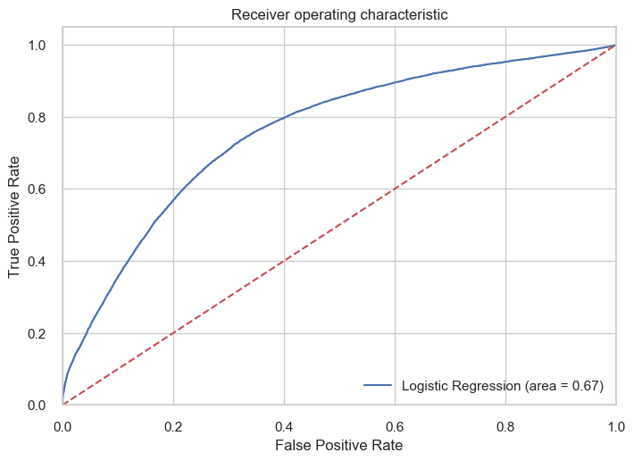

```python
# ROC Curve
from sklearn.metrics import roc_auc_score
from sklearn.metrics import roc_curve

logit_roc_auc = roc_auc_score(y_test, logreg.predict(X_test))
fpr, tpr, thresholds = roc_curve(y_test, logreg.predict_proba(X_test)[:,1])
plt.figure()
plt.plot(fpr, tpr, label='Logistic Regression (area = %0.2f)' % logit_roc_auc)
plt.plot([0, 1], [0, 1],'r--')
plt.xlim([0.0, 1.0])
plt.ylim([0.0, 1.05])
plt.xlabel('False Positive Rate')
plt.ylabel('True Positive Rate')
plt.title('Receiver operating characteristic')
plt.legend(loc="lower right")
plt.savefig('ROC_graph')
plt.show()
```

## Random Forest

Back to Top

```python
# Temp Dataset for Random Forest.  Dropped the highly correlated features.  Replace NaN with mean of column
#rf_df = df.drop(['x41', 'x6'], axis=1)
#rf_df = rf_df.fillna(lr_df.mean())

rf_df = lr_df

# One-hot encode the data using pandas get_dummies
#features = pd.get_dummies(rf_df)

# Display the first 5 rows of the last 12 columns
#features.iloc[:,5:].head(5)
```

```python
# Feature of Importance
# ref: https://towardsdatascience.com/running-random-forests-inspect-the-feature-importances-with-this-code-2b00dd72b92e

y = lr_df['y']
X = lr_df.drop('y', axis = 1)

# Splitting data set
X_train, X_test, y_train, y_test = train_test_split(X, y, test_size=0.3, random_state=123)

## Import the random forest model.
from sklearn.ensemble import RandomForestClassifier

## Initiating Random Forest Classifier.
rf = RandomForestClassifier()

## Fitting model on training data.
rf.fit(X_train, y_train)

## Accuracy Score
rf.score(X_test, y_test)
```

```
0.8817916666666666
```

```python
feature_importances = pd.DataFrame(rf.feature_importances_,
                                   index = X_train.columns,
                                   columns=['importance']).sort_values('importance', ascending=False)
print(feature_importances)
```

```
       importance
x23      0.077181
x49      0.065839
x48      0.060268
x20      0.058518
x37      0.055289
x42      0.053919
x12      0.050128
x38      0.048655
x27      0.047629
x7       0.047552
x40      0.046721
x28      0.044268
x46      0.042702
x2       0.035570
x4       0.009136
x34      0.009089
x8       0.009086
x13      0.008987
x16      0.008966
x36      0.008948
x33      0.008919
x14      0.008859
x21      0.008859
x3       0.008858
x1       0.008832
x43      0.008814
x31      0.008763
x35      0.008725
x44      0.008722
x45      0.008712
x26      0.008698
x17      0.008691
x9       0.008688
x10      0.008659
x0       0.008655
x19      0.008626
x47      0.008613
x22      0.008566
x25      0.008550
x15      0.008540
x18      0.008406
x39      0.008316
x11      0.008293
x5       0.008172
month    0.004014
```

## Decision Tree

Back to Top

```python
dt = DecisionTreeClassifier(random_state=123)
dt.fit(X_train, y_train)
```

```
DecisionTreeClassifier(class_weight=None, criterion='gini', max_depth=None,
            max_features=None, max_leaf_nodes=None,
            min_impurity_decrease=0.0, min_impurity_split=None,
            min_samples_leaf=1, min_samples_split=2,
            min_weight_fraction_leaf=0.0, presort=False, random_state=123,
            splitter='best')
```

```python
y_pred = dt.predict(X_test)
print ("Accuracy is ", accuracy_score(y_test,y_pred)*100, 'with Gini Index.')
```

```
Accuracy is  83.75416666666666 with Gini Index.
```

```python
dt_ent = DecisionTreeClassifier(criterion='entropy',random_state=123)
dt_ent.fit(X_train, y_train)
```

```
DecisionTreeClassifier(class_weight=None, criterion='entropy', max_depth=None,
            max_features=None, max_leaf_nodes=None,
            min_impurity_decrease=0.0, min_impurity_split=None,
            min_samples_leaf=1, min_samples_split=2,
            min_weight_fraction_leaf=0.0, presort=False, random_state=123,
            splitter='best')
```

```python
y_pred = dt_ent.predict(X_test)
print ("Accuracy is ", accuracy_score(y_test,y_pred)*100, 'with Information Gain.')
```

```
Accuracy is  84.09791666666668 with Information Gain.
```

## Decision Tree, Logistic Regressions, and Random Forest using Features of Importance

Back to Top

```python
# Subsetting by feature of importance from RF
#rf_df_1 = lr_df [['x23', 'x12', 'x20', 'x48', 'x49', 'x27', 'x28','x37', 'x38', 'x42', 'x2', 'x7' ,'x46', 'x40', 'y']]

# importance > .04
rf_df_1 = lr_df [['x23', 'x20', 'x48', 'x49', 'x38', 'x12', 'x42', 'x27','x40', 'x37','x28','x7','x2', 'x46', 'y']]

#rf_df_1 = lr_df [['x23', 'x20', 'x48', 'x49', 'x38', 'y']] - this set yielded a worse accuracy. importance > 0.05
print(rf_df_1.head())
print(rf_df_1.shape)
```

```
         x23       x20       x48        x49        x38        x12       x42  \
0   3.553013 -1.909114  0.151589  -8.040166  -1.353729  25.665413  5.414063
1  10.590601 -5.809984 -0.320283  16.719974  32.816804 -25.014934  4.490915
2  -5.270615  1.700321 -2.090804  -7.869421  -0.333199  12.078602  9.088864
3 -11.484431  1.923670  1.806070  -7.670847  14.188669  10.995330 -7.467775
4 -15.998166 -9.026317 -0.894942  15.724742 -12.578926 -28.106348 -5.229937

        x27        x40      x37        x28         x7         x2        x46  y
0  1.005131 -10.612200  1313.96 -18.473784 -14.789997   4.621113  60.781427  0
1  0.751086   2.147427  1962.78   3.749377  -6.725709  27.839856  15.805696  0
2  4.171088  -0.863137   430.47  11.522448  11.060572  12.251561  30.856417  0
3  9.215569  12.084421 -2366.29  30.595226 -18.913592 -24.149632 -72.424569  0
4  1.811182  30.004727  -620.66  -4.094084  27.532281 -11.352593 -14.085435  1
(160000, 15)
```

### Decision Tree w/ Feature of Importance

```python
#y_1 = rf_df_1['y']
#X_1 = rf_df_1.drop('y', axis = 1)

#rf_df_sample = rf_df.sample(frac=.95)

y_1 = rf_df_1['y']
X_1 = rf_df_1.drop('y', axis = 1)

# Model Fitting
X_train1, X_test1, y_train1, y_test1 = train_test_split(X_1, y_1, test_size=0.3, random_state=123)
```

```python
dt = DecisionTreeClassifier(random_state=123)
dt.fit(X_train1, y_train1)
y_pred1 = dt.predict(X_test1)
print ("Accuracy is ", accuracy_score(y_test1,y_pred1)*100, 'with Gini Index.')
```

```
Accuracy is  85.87708333333333 with Gini Index.
```

```python
dt_ent = DecisionTreeClassifier(criterion='entropy',random_state=123)
dt_ent.fit(X_train1, y_train1)
y_pred1 = dt_ent.predict(X_test1)
print ("Accuracy is ", accuracy_score(y_test1,y_pred1)*100, 'with Information Gain.')
```

```
Accuracy is  86.03541666666666 with Information Gain.
```

```python
n_est = [5, 10, 11,12,13,14,15, 16, 17,18,19, 20, 22, 25, 50, 100]
for n in n_est :
    dt = DecisionTreeClassifier(random_state=123, max_depth = n)
    dt.fit(X_train1, y_train1)
    y_pred1 = dt.predict(X_test1)
    print ("Accuracy is ", accuracy_score(y_test1,y_pred1)*100, 'with Gini Index at', n, 'depth')
```

```
Accuracy is  76.93541666666667 with Gini Index at 5 depth
Accuracy is  84.64791666666667 with Gini Index at 10 depth
Accuracy is  85.25416666666666 with Gini Index at 11 depth
Accuracy is  86.15416666666667 with Gini Index at 12 depth
Accuracy is  86.34791666666666 with Gini Index at 13 depth
Accuracy is  86.65625 with Gini Index at 14 depth
Accuracy is  86.85208333333333 with Gini Index at 15 depth
Accuracy is  86.55000000000001 with Gini Index at 16 depth
Accuracy is  86.69583333333334 with Gini Index at 17 depth
Accuracy is  86.63125000000001 with Gini Index at 18 depth
Accuracy is  86.47083333333333 with Gini Index at 19 depth
Accuracy is  86.41041666666666 with Gini Index at 20 depth
Accuracy is  86.21041666666667 with Gini Index at 22 depth
Accuracy is  85.95208333333333 with Gini Index at 25 depth
Accuracy is  85.87708333333333 with Gini Index at 50 depth
Accuracy is  85.87708333333333 with Gini Index at 100 depth
```

```python
n_est = [5, 10, 11,12,13,14,15, 16, 17,18,19, 20, 22, 25, 50, 100]
for n in n_est :
    dt = DecisionTreeClassifier(criterion = 'entropy',random_state=123, max_depth = n)
    dt.fit(X_train1, y_train1)
    y_pred1 = dt.predict(X_test1)
    print ("Accuracy is ", accuracy_score(y_test1,y_pred1)*100, 'with Information Gain at', n, 'depth')
```

```
Accuracy is  76.02499999999999 with Information Gain at 5 depth
Accuracy is  83.61041666666667 with Information Gain at 10 depth
Accuracy is  84.32916666666667 with Information Gain at 11 depth
Accuracy is  85.00208333333333 with Information Gain at 12 depth
Accuracy is  85.55416666666666 with Information Gain at 13 depth
Accuracy is  85.77291666666666 with Information Gain at 14 depth
Accuracy is  86.38958333333333 with Information Gain at 15 depth
Accuracy is  86.33541666666666 with Information Gain at 16 depth
Accuracy is  86.3 with Information Gain at 17 depth
Accuracy is  86.22916666666667 with Information Gain at 18 depth
Accuracy is  86.25625 with Information Gain at 19 depth
Accuracy is  86.12291666666667 with Information Gain at 20 depth
Accuracy is  86.17291666666667 with Information Gain at 22 depth
Accuracy is  85.99166666666666 with Information Gain at 25 depth
Accuracy is  86.03541666666666 with Information Gain at 50 depth
Accuracy is  86.03541666666666 with Information Gain at 100 depth
```

### Logistic Regression w/ Feature of Importance

Back to Top

```python
logreg = LogisticRegression(random_state=123)
logreg.fit(X_train1, y_train1)
```

```
LogisticRegression(C=1.0, class_weight=None, dual=False, fit_intercept=True,
          intercept_scaling=1, max_iter=100, multi_class='warn',
          n_jobs=None, penalty='l2', random_state=123, solver='warn',
          tol=0.0001, verbose=0, warm_start=False)
```

```python
y_pred1 = logreg.predict(X_test1)
print('Accuracy of logistic regression classifier on test set: {:.2f}'.format(logreg.score(X_test1, y_test1)*100), '%')
```

```
Accuracy of logistic regression classifier on test set: 70.33 %
```

```python
# Confusion Matrix
from sklearn.metrics import confusion_matrix
confusion_matrix = confusion_matrix(y_test1, y_pred1)
print(confusion_matrix)
```

```
[[23838  4998]
 [ 9243  9921]]
```

```python
# Compute Precision, recall, F-Measure and Support
from sklearn.metrics import classification_report
print(classification_report(y_test1, y_pred1))
```

```
              precision    recall  f1-score   support

           0       0.72      0.83      0.77     28836
           1       0.66      0.52      0.58     19164

   micro avg       0.70      0.70      0.70     48000
   macro avg       0.69      0.67      0.68     48000
weighted avg       0.70      0.70      0.70     48000
```

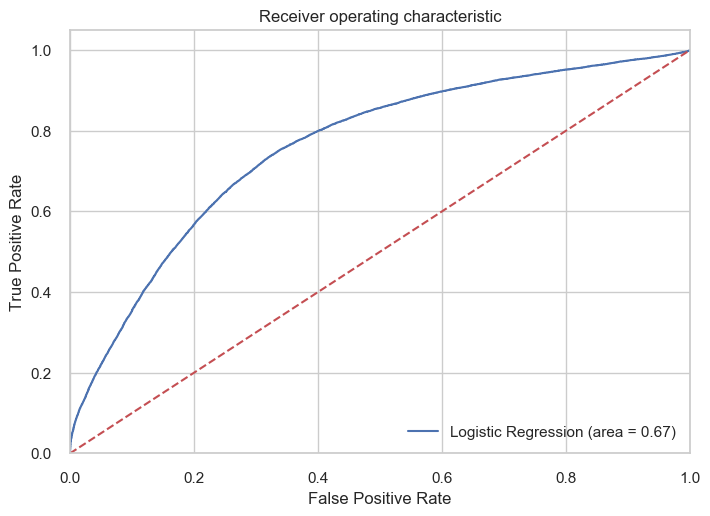

```python
# ROC Curve
logit_roc_auc = roc_auc_score(y_test1, logreg.predict(X_test1))
fpr, tpr, thresholds = roc_curve(y_test1, logreg.predict_proba(X_test1)[:,1])
plt.figure()
plt.plot(fpr, tpr, label='Logistic Regression (area = %0.2f)' % logit_roc_auc)
plt.plot([0, 1], [0, 1],'r--')
plt.xlim([0.0, 1.0])
plt.ylim([0.0, 1.05])
plt.xlabel('False Positive Rate')
plt.ylabel('True Positive Rate')
plt.title('Receiver operating characteristic')
plt.legend(loc="lower right")
plt.savefig('ROC_graph_FI')
plt.show()
```

### Random Forest w/ Feature Selection

Back to Top

```python
## Import the random forest model.
from sklearn.ensemble import RandomForestClassifier

## Initiating Random Forest Classifier.
rf = RandomForestClassifier()

## Fitting model on training data.
rf.fit(X_train1, y_train1)

## Accuracy Score
rf.score(X_test1, y_test1)
```

```
0.9131458333333333
```

## Principal Component Analysis (PCA)

Back to Top

```python
df_PCA = lr_df

#variables to be drop
#categoricals ('continent', 'day', 'month')
#highly correlated ('x6', 'x41')
#derived ('Total')
#target ('y')
r_variables = ['month', 'y']

target = df_PCA['y']
#drop variables
explainatory = df_PCA.drop(r_variables, axis=1)

#scale explanatory variables (mean = 0, variance = 1)
scaler = StandardScaler().fit(explainatory)

# Apply transform to variables.
train = scaler.transform(explainatory)
```

```python
pca = PCA().fit(explainatory)
pca_t = pca.transform(explainatory)
```

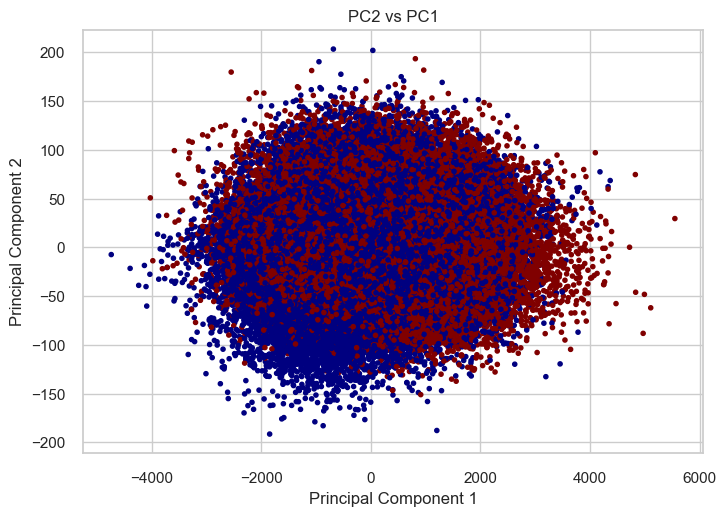

```python
import matplotlib.pyplot as plt

#plot component 1 vs component 2
f = plt.figure()
plt.scatter(pca_t[:, 0], pca_t[:, 1], c=target, marker='.', cmap='jet')
plt.title('PC2 vs PC1')
plt.xlabel('Principal Component 1')
plt.ylabel('Principal Component 2')

f.savefig("scatter.png", bbox_inches='tight')
```

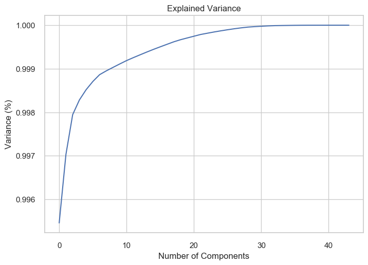

```python
# Source: https://towardsdatascience.com/an-approach-to-choosing-the-number-of-components-in-a-principal-component-analysis-pca-3b9f3d6e73fe

#Plotting the Cumulative Summation of the Explained Variance
f = plt.figure()
plt.plot(np.cumsum(pca.explained_variance_ratio_))
plt.xlabel('Number of Components')
plt.ylabel('Variance (%)') #for each component
plt.title('Explained Variance')

f.savefig("variance.png", bbox_inches='tight')
```

```python
pca_df = pd.DataFrame(pca_t[:,])
pca_df.to_csv("pca_df.csv", sep=',', encoding='utf-8')
```

## Support Vector Machine (SVM)

#### Note: Too computationally expensive to run - decided to exclude from final deliverable

Back to Top

```python
#SVM
#Source: https://stackabuse.com/implementing-svm-and-kernel-svm-with-pythons-scikit-learn/

#random.seed(2019)
# split data into training and test set
#train, test, train_target, test_target = train_test_split(pca_df, target, test_size=.2)
```

```python
#linearly separable data

#svclassifier = SVC(kernel='linear')
#svclassifier.fit(train, train_target)

#y_pred = svclassifier.predict(test)


#print(confusion_matrix(test_target,y_pred))
#print(classification_report(test_target,y_pred))
```

```python
#non-linearly separable data, gaussian kernel

#svclassifier = SVC(kernel='rbf')
#svclassifier.fit(train, train_target)

#y_pred = svclassifier.predict(test)


#print(confusion_matrix(test_target,y_pred))
#print(classification_report(test_target,y_pred))
```

```python
#non-linearly separable data, sigmoid kernel

#svclassifier = SVC(kernel='sigmoid')
#svclassifier.fit(train, train_target)

#y_pred = svclassifier.predict(test)


#print(confusion_matrix(test_target,y_pred))
#print(classification_report(test_target,y_pred))
```

```python
#non-linearly separable data, polynomial kernel

#for degree in range(2,6):
#    svclassifier = SVC(kernel='poly', degree=degree)
#    svclassifier.fit(train, train_target)

#    y_pred = svclassifier.predict(test)

#    print(degree)
#    print(confusion_matrix(test_target,y_pred))
#    print(classification_report(test_target,y_pred))
```

## kNN - full dataset (minus EDA findings) - k=5

Back to Top

```python
knn_df=df.drop(['x41', 'x6', 'month', 'continent', 'day','x32'], axis=1)

# Fill in NA with mean - LR needs values in each cell
#knn_df = knn_df.fillna(df.mean())

# Alternative - Drop all rows with NA
knn_df = knn_df.dropna()

#Create x and y

y = knn_df['y']
x = knn_df.drop('y', axis = 1)
```

```python
#TrainTestSplit

x_train, x_test, y_train, y_test = train_test_split(x, y, test_size=0.30, random_state=123)
```

```python
#feature scaling

scaler=StandardScaler()
scaler.fit(x_train)

x_train = scaler.transform(x_train)
x_test=scaler.transform(x_test)
```

```python
#Training and Predictions
classifier = KNeighborsClassifier(n_neighbors=5)
classifier.fit(x_train, y_train)
```

```
KNeighborsClassifier(algorithm='auto', leaf_size=30, metric='minkowski',
           metric_params=None, n_jobs=None, n_neighbors=5, p=2,
           weights='uniform')
```

```python
y_pred=classifier.predict(x_test)
```

```python
from mlxtend.plotting import plot_confusion_matrix

#Evaluating Results
print("Accuracy:",metrics.accuracy_score(y_test, y_pred))
print(confusion_matrix(y_test, y_pred))
print(classification_report(y_test, y_pred))
```

```
Accuracy: 0.7981880859292891
[[24430  4119]
 [ 5482 13543]]
              precision    recall  f1-score   support

           0       0.82      0.86      0.84     28549
           1       0.77      0.71      0.74     19025

   micro avg       0.80      0.80      0.80     47574
   macro avg       0.79      0.78      0.79     47574
weighted avg       0.80      0.80      0.80     47574
```

### Accuracy = 79.81%

## kNN Loop k=1-25 to find the best K value - using subset of data from Random Forest features

```python
#Subset by RF important features >.04
knn_importance_df = knn_df[['x23', 'x20', 'x48', 'x49', 'x38', 'x12', 'x42', 'x27','x40', 'x37','x28','x7','x2', 'x46', 'y']]
```

```python
#Create x and y

y = knn_importance_df['y']
x = knn_importance_df.drop('y', axis = 1)
```

```python
#TrainTestSplit

x_train, x_test, y_train, y_test = train_test_split(x, y, test_size=0.20, random_state=1234)
```

```python
#feature scaling

scaler=StandardScaler()
scaler.fit(x_train)

x_train = scaler.transform(x_train)
x_test=scaler.transform(x_test)
```

```python
#source: https://www.ritchieng.com/machine-learning-k-nearest-neighbors-knn/
# try K=1 through K=25 and record testing accuracy
k_range = range(1, 26)

# We can create Python dictionary using [] or dict()
scores = []

for k in k_range:
    knn = KNeighborsClassifier(n_neighbors=k)
    knn.fit(x_train, y_train)
    y_pred = knn.predict(x_test)
    scores.append(metrics.accuracy_score(y_test, y_pred))

print(scores)
```

```
[0.9317063942489595, 0.9294047168621516, 0.9466515323496028, 0.9439714970361962, 0.9485433219825955, 0.9469668306217682, 0.9493315676630092, 0.9479127254382645, 0.9485433219825955, 0.9477550763021818, 0.9488901500819775, 0.9489216799091941, 0.9492369781813595, 0.94822802371043, 0.9488270904275444, 0…
```

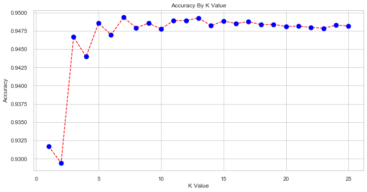

```python
#Visualize it
# Source: https://stackabuse.com/k-nearest-neighbors-algorithm-in-python-and-scikit-learn/

plt.figure(figsize=(12, 6))
plt.plot(range(1, 26), scores, color='red', linestyle='dashed', marker='o',
         markerfacecolor='blue', markersize=10)
plt.title('Accuracy By K Value')
plt.xlabel('K Value')
plt.ylabel('Accuracy')
plt.savefig('KNN_Accuracy.png')
```

## kNN - k=9 on subset of data

```python
#Create x and y

y = knn_importance_df['y']
x = knn_importance_df.drop('y', axis = 1)
```

```python
#TrainTestSplit

x_train, x_test, y_train, y_test = train_test_split(x, y, test_size=0.2, random_state=1234)
```

```python
#feature scaling

scaler=StandardScaler()
scaler.fit(x_train)

x_train = scaler.transform(x_train)
x_test=scaler.transform(x_test)
```

```python
#Training and Predictions
classifier = KNeighborsClassifier(n_neighbors=9)
classifier.fit(x_train, y_train)
```

```
KNeighborsClassifier(algorithm='auto', leaf_size=30, metric='minkowski',
           metric_params=None, n_jobs=None, n_neighbors=9, p=2,
           weights='uniform')
```

```python
y_pred=classifier.predict(x_test)
```

```python
#Evaluating Results
print("Accuracy:",metrics.accuracy_score(y_test, y_pred))
print(confusion_matrix(y_test, y_pred))
print(classification_report(y_test, y_pred))
```

```
Accuracy: 0.9485433219825955
[[18229   749]
 [  883 11855]]
              precision    recall  f1-score   support

           0       0.95      0.96      0.96     18978
           1       0.94      0.93      0.94     12738

   micro avg       0.95      0.95      0.95     31716
   macro avg       0.95      0.95      0.95     31716
weighted avg       0.95      0.95      0.95     31716
```

[figure not shown]

```python
binary = np.array([[18394, 714],
                   [831, 12061]])

class_names = ['y=0', 'y=1']
fig, ax = plot_confusion_matrix(conf_mat=binary,
                                show_absolute=True,
                                show_normed=True,
                                colorbar=True,
                               class_names=class_names,
                               figsize=(8,8))
plt.title('KNN Confusion Matrix')
plt.savefig('KNN_Matrix.png')
plt.show()
```

```python
# Read in CSV
df = pd.read_csv("pca_df.csv")
print(len(df))
```

```
159972
```

```python
PCAdf=df[['0', '1', '2', '3', '4', '5', '6', '7', '8', 'y']]
PCAdf.head()
```

[output not shown]

```python
#Create x and y

y = PCAdf['y']
x = PCAdf.drop('y', axis = 1)
```

```python
#TrainTestSplit

x_train, x_test, y_train, y_test = train_test_split(x, y, test_size=0.2, random_state=1234)
```

```python
#feature scaling

scaler=StandardScaler()
scaler.fit(x_train)

x_train = scaler.transform(x_train)
x_test=scaler.transform(x_test)
```

```python
#Training and Predictions
classifier = KNeighborsClassifier(n_neighbors=9)
classifier.fit(x_train, y_train)
```

```
KNeighborsClassifier(algorithm='auto', leaf_size=30, metric='minkowski',
           metric_params=None, n_jobs=None, n_neighbors=9, p=2,
           weights='uniform')
```

```python
y_pred=classifier.predict(x_test)
```

```python
#Evaluating Results
print("Accuracy:",metrics.accuracy_score(y_test, y_pred))
print(confusion_matrix(y_test, y_pred))
print(classification_report(y_test, y_pred))
```

```
Accuracy: 0.8501328332551962
[[17030  2264]
 [ 2531 10170]]
              precision    recall  f1-score   support

         0.0       0.87      0.88      0.88     19294
         1.0       0.82      0.80      0.81     12701

   micro avg       0.85      0.85      0.85     31995
   macro avg       0.84      0.84      0.84     31995
weighted avg       0.85      0.85      0.85     31995
```

### Accuracy = 85.01

## XGBoost

#### note: There is a tendancy for XGBoost to kill the kernal. Run at your risk. We ran it and got an accuracy of 83.12%

Back to Top

```python
#import os
#os.environ['KMP_DUPLICATE_LIB_OK']='True'
#from xgboost import XGBClassifier
```

```python
#y_xg = knn_importance_df['y']
#x_xg = knn_importance_df.drop('y', axis = 1)
```

```python
#TrainTestSplit

#X_train, X_test, y_train, y_test = train_test_split(x_xg, y_xg, test_size=0.2, random_state=1234)
```

```python
# fit model no training data
#model = XGBClassifier()
#model.fit(X_train, y_train)
```

```python
#print(model)
```

```python
# make predictions for test data
#y_pred = model.predict(X_test)
#predictions = [round(value) for value in y_pred]
```

```python
# evaluate predictions
#accuracy = accuracy_score(y_test, predictions)
#print("Accuracy: %.2f%%" % (accuracy * 100.0))
```